# Fusion Education

- Instructor: Hui (Henry) Chen and Peggy
- Time: Saturday 11:30 AM - 12:30 PM
- Python version: 3.9.x

Topics:

1. Comments
2. Variables
3. String Formatting
4. *Methods*: print(), format()

# Comments

Questions

1. What is a comment?
2. Why do we need to comment?

## Single line comment

```python
# This is a comment.
# This is the second line of comments.
```

It is recommended to have a space in between the # and your comment message.

e.g., **not recommended** one could be:

```python
#Today is sunny
```

e.g., **recommended** one could be:

```python
# Today is sunny
```

## Multiple line comments

Sometimes, one line comment is not enough to write/leave a message, so we need to have multiple line comments.

```python
'''
    This is my first multiple line comments.
    I can jump to the next line to start to write my next comment.
'''
```

```
'\n    This is my first multiple line comments.\n    I can jump to the next line to start to write my next comment.\n'
```

However, in Python, there are two ways to write multiple line comments, and they are as follow:

- Three single quote: '''
- Three double quote: """

```python
"""
    This is my first multiple line comments.,
    I can jump to the next line to start to write my next comment.
"""
```

```
'\n    This is my first multiple line comments.,\n    I can jump to the next line to start to write my next comment.\n'
```

Also, I can use single # to have multple line comments.

```python
# Today is cloudy.
# My bedroom is very humid :(
```

# Variables

## Get Started

Questions

- What is a variable?
- In the following three options, where do the variables stored?
  - CPU
  - RAM
  - Storage

How to create a variable in Python?

**Rules on how to name a variable**

1. It can be only one word.
2. It can use only letters, numbers, and the underscore (_) character.
3. It can end with a number or the underscore (_) character.
4. It can’t begin with a number.
5. It can’t contain any special characters.

**Rules on how to give a variable value**

1. Number do not need single/double quote.
2. Text data value need single/double quote.

```python
# examples

# variables with number values

Henry_age = 24
Sean_age = 10
weather = 109.92

# variables with text values
name1 = "Henry"
name2 = "Sean"
name3 = "William"

# more examples
pizza999 = 94.23
noodles837 = 442
```

Note, it is recommended to create a variable with all lower case unless it's special variable. e.g., a person's name or a variable that will not change its value.

With the variables that will not change its value, we always make the variable name all upper case! And, we call it as a **constant**!

e.g., a variable that will never change its value forever would be $\pi$

```python
PI = 3.1415
```

## *print()*

In programming, we are able to output the result that we want to display on the screen. In order to do it, we can use Python's built-in function *print()*.

Just like that, we simply put whatever we want inside the parentheses.

```python
# example
print(Henry_age)
```

```
24
```

# String Formatting

Questions

- What is a string?
- What is string formatting?

String formatting is a custom text or variable in predefined text.

## String Slice

- Take part of the string

### Access single letter

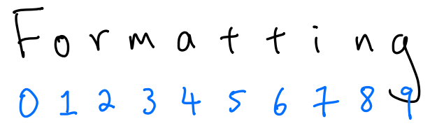

```python
example = "Formatting"


print(example)
# print(example[1])
```

```
Formatting
```

### Access part of the text

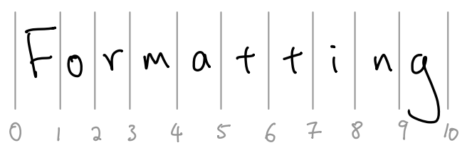

Access the slice through [] where we specify the range that we want to access.

```python
print(example)
# print(example[5:6])
```

```
Formatting
```

### Access the single letter (backward)

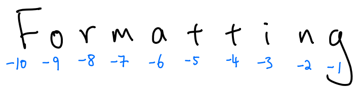

```python
print(example)
# print(example[-6])
```

```
Formatting
```

### Access part of the text

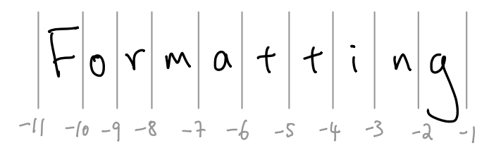

```python
print(example)
# print(example[-4:-1])
```

```
Formatting
```

## *format()*

Sometimes, we may want to print more than just the value of the variable. Therefore, *format()* method could be very helpful here!

```python
print(name1)
```

```
Henry
```

```python
print("My name is {}".format(name1))
```

```
My name is Henry
```